# Fallen Angel Analysis

## Packages

```r
invisible(require("zoo"))
invisible(require("MSwM"))
invisible(require("lubridate"))
```

```r
invisible(require("ggplot2"))
invisible(require("reshape2"))
invisible(require("tidyverse"))
invisible(require("roll"))
```

## Path Management

```r
parent_dir <- normalizePath("..")
data_dir <- paste0(parent_dir, "\\data")
file_path <- paste0(data_dir, "\\fallen_angels.csv")
df_raw <- read.csv(file_path)
```

## Exploratory Data Analysis

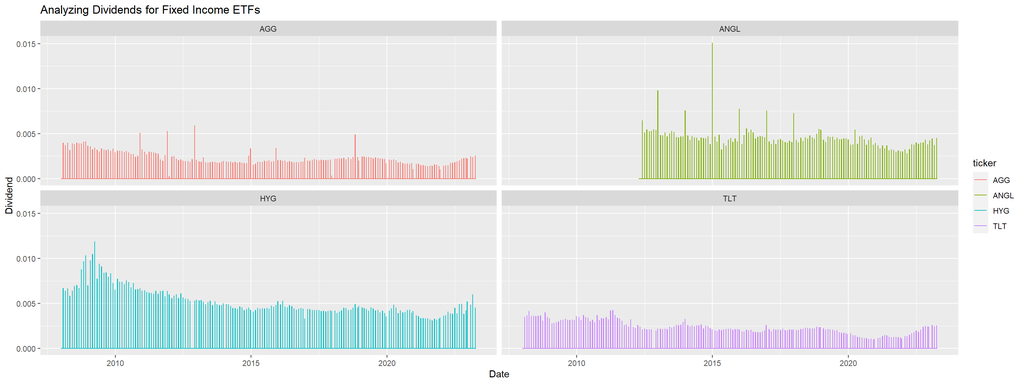

```r
df_prep <- df_raw %>%
  tibble() %>%
  rename("quote" = "variable_0", "ticker" = "variable_1", "price" = "value") %>%
  mutate(Date = as.Date(Date))

# we are going to use BND as our benchmark index for calculating betas
df_benchmark <- df_prep %>%
  filter(quote == "Adj Close", ticker == "BND")

df_securities <- df_prep %>%
  filter(ticker != "BND")

# want to check and see if they pay dividends
close_rtn <- df_securities %>%
  filter(quote == "Close") %>%
  group_by(ticker) %>%
  mutate(close_rtn = price / lag(price) - 1) %>%
  select(Date, ticker, close_rtn) %>%
  ungroup()

adj_close_rtn <- df_prep %>%
  filter(quote == "Adj Close") %>%
  group_by(ticker) %>%
  mutate(adj_close_rtn = price / lag(price) - 1) %>%
  select(Date, ticker, adj_close_rtn) %>%
  ungroup()

df_dividend <- close_rtn %>%
  left_join(
    adj_close_rtn,
    by = c("ticker", "Date")) %>%
  drop_na() %>%
  mutate(diff = adj_close_rtn - close_rtn)

df_dividend_plot <- df_dividend %>%
  select(Date, ticker, diff)

dividend_plot <- ggplot(df_dividend_plot, aes(x = Date, y = diff, color = ticker)) +
  geom_line() +
  facet_wrap(~ticker) +
  labs(y = "Dividend", title = "Analyzing Dividends for Fixed Income ETFs")

dividend_plot
```

## Get Returns

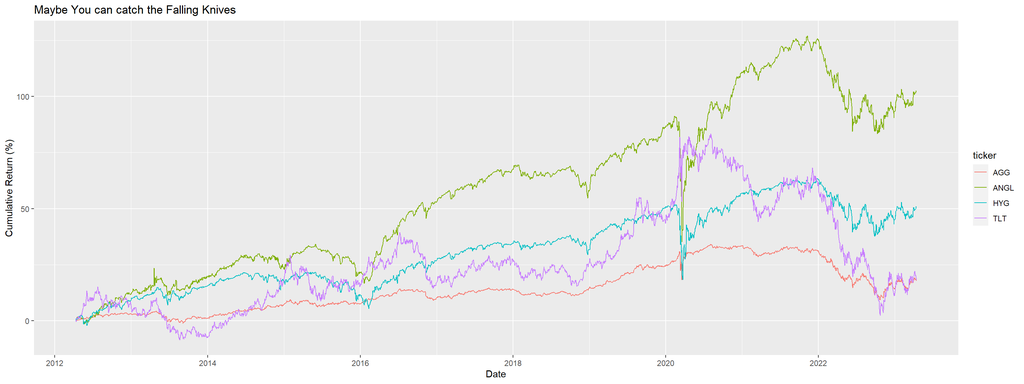

```r
df_rtn <- df_securities %>%
  filter(quote == "Adj Close") %>%
  select(-quote, -X) %>%
  pivot_wider(names_from = "ticker", values_from = "price") %>%
  drop_na() %>%
  melt(id.vars = "Date", variable.name = "ticker", value.name = "price") %>%
  group_by(ticker) %>%
  mutate(
    rtn = price / lag(price) - 1,
    cum_rtn = (cumprod(1 + replace_na(rtn, 0)) - 1) * 100)

df_plot <- df_rtn %>%
  select(Date, ticker, cum_rtn)

return_plot <- ggplot(df_plot, aes(x = Date, y = cum_rtn, color = ticker)) +
  geom_line() +
  labs(y = "Cumulative Return (%)", title = "Maybe You can catch the Falling Knives")

return_plot
```

## Let’s look at the returns on a year basis

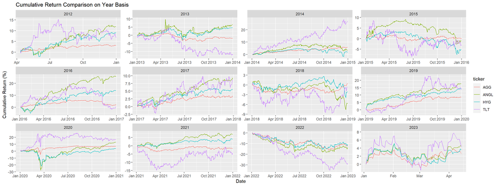

```r
df_rtn_yoy <- df_rtn %>%
  select(Date, ticker, price) %>%
  mutate(year = format(Date, format = "%Y")) %>%
  group_by(ticker, year) %>%
  mutate(
    rtn = price / lag(price) - 1,
    cum_rtn = (cumprod(1 + replace_na(rtn, 0)) - 1) * 100)

df_yoy_plot <- df_rtn_yoy %>%
  select(Date, ticker, year, cum_rtn)

yearly_plot <- ggplot(df_yoy_plot, aes(x = Date, y = cum_rtn, color = ticker)) +
  geom_line() +
  facet_wrap(~year, scales = "free") +
  labs(y = "Cumulative Return (%)", title = "Cumulative Return Comparison on Year Basis")

yearly_plot
```

## Let’s Look at the Spread

```r
df_spread_rtn <- df_rtn %>%
  mutate(rtn = replace_na(rtn, 0)) %>%
  select(Date, ticker, rtn) %>%
  pivot_wider(names_from = ticker, values_from = rtn) %>%
  mutate(
    angl_agg = (0.5 * ANGL) - (0.5 * AGG),
    angl_hyg = (0.5 * ANGL) - (0.5 * HYG),
    angl_tlt = (0.5 * ANGL) - (0.5 * TLT)) %>%
  select(Date, angl_agg, angl_hyg, angl_tlt) %>%
  melt(id.vars = "Date", variable.name = "ticker", value.name = "rtn") %>%
  mutate(ticker = case_when(
    ticker == "angl_agg" ~ "Long ANGL short AGG",
    ticker == "angl_hyg" ~ "Long ANGL short HYG",
    ticker == "angl_tlt" ~ "Long ANGL short TLT"))

df_tot_rtn <- df_spread_rtn %>%
  group_by(ticker) %>%
  mutate(cum_rtn = (cumprod(1 + rtn) - 1) * 100) %>%
  select(Date, ticker, cum_rtn)

spread_graph <- ggplot(df_tot_rtn, aes(x = Date, y = cum_rtn, color = ticker)) +
  geom_line() +
  labs(y = "Cumulative Return (%)", title = "Buying the Fallen Angel Spread (Long 50% ANGL Short 50% Other, Rebalance Daily)")
```

## Let’s look at that spread on Year-by-Year basis

```r
df_spread_yoy <- df_spread_rtn %>%
  mutate(year = format(Date, format = "%Y")) %>%
  group_by(year, ticker) %>%
  mutate(cum_rtn = (cumprod(1 + rtn) - 1) * 100) %>%
  select(Date, ticker, cum_rtn, year)

yby_spread_plot <- ggplot(df_spread_yoy, aes(x = Date, y = cum_rtn, color = ticker)) +
  geom_line() +
  facet_wrap(~year, scale = "free") +
  labs(y = "Cumulative Return (%)", title = "Fallen Angel spreads per each year")
```

## Run Regression on bonds

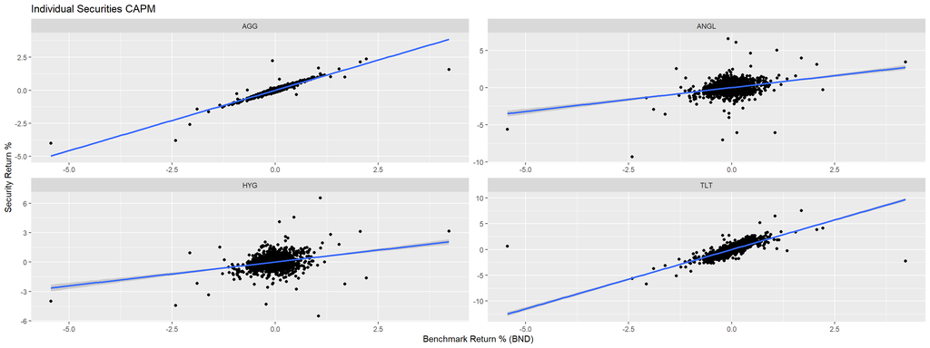

```r
first_date <- df_spread_rtn$Date %>% min()
benchmark_rtn <- df_benchmark %>%
  filter(Date >= first_date) %>%
  mutate(benchmark_rtn = replace_na(price / lag(price) - 1,0)) %>%
  select(Date, benchmark_ticker = ticker, benchmark_rtn)

df_rtn_combined <- df_rtn %>%
  left_join(benchmark_rtn, by = "Date") %>%
  mutate(
    rtn = rtn * 100,
    benchmark_rtn = benchmark_rtn * 100)

ggplot(df_rtn_combined, aes(x = benchmark_rtn, y = rtn)) +
  geom_point() +
  geom_smooth(method = "lm") +
  facet_wrap(~ticker, scale = "free") +
  labs(x = "Benchmark Return % (BND)", y = "Security Return %",
       title = "Individual Securities CAPM")
```

## Regression Results

```r
benchmark_val <- benchmark_rtn$benchmark_rtn
agg_rtns <- (df_rtn_combined %>% filter(ticker == "AGG"))$rtn
angl_rtns <- (df_rtn_combined %>% filter(ticker == "ANGL"))$rtn
hyg_rtns <- (df_rtn_combined %>% filter(ticker == "HYG"))$rtn
tlt_rtns <- (df_rtn_combined %>% filter(ticker == "TLT"))$rtn
```

```r
agg_lm = lm(agg_rtns~benchmark_val)
summary(agg_lm)
```

```
##
## Call:
## lm(formula = agg_rtns ~ benchmark_val)
##
## Residuals:
##      Min       1Q   Median       3Q      Max
## -2.28259 -0.03345 -0.00043  0.03235  2.28905
##
## Coefficients:
##                Estimate Std. Error t value Pr(>|t|)
## (Intercept)   6.635e-04  1.836e-03   0.361    0.718
## benchmark_val 9.130e+01  6.050e-01 150.912   <2e-16 ***
## ---
## Signif. codes:  0 '***' 0.001 '**' 0.01 '*' 0.05 '.' 0.1 ' ' 1
##
## Residual standard error: 0.09662 on 2768 degrees of freedom
##   (1 observation deleted due to missingness)
## Multiple R-squared:  0.8916, Adjusted R-squared:  0.8916
## F-statistic: 2.277e+04 on 1 and 2768 DF,  p-value: < 2.2e-16
```

```r
angl_lm = lm(angl_rtns~benchmark_val)
summary(angl_lm)
```

```
##
## Call:
## lm(formula = angl_rtns ~ benchmark_val)
##
## Residuals:
##     Min      1Q  Median      3Q     Max
## -7.7813 -0.2369  0.0123  0.2474  6.6481
##
## Coefficients:
##               Estimate Std. Error t value Pr(>|t|)
## (Intercept)    0.02342    0.01144   2.048   0.0406 *
## benchmark_val 64.37018    3.76777  17.084   <2e-16 ***
## ---
## Signif. codes:  0 '***' 0.001 '**' 0.01 '*' 0.05 '.' 0.1 ' ' 1
##
## Residual standard error: 0.6017 on 2768 degrees of freedom
##   (1 observation deleted due to missingness)
## Multiple R-squared:  0.09539,    Adjusted R-squared:  0.09506
## F-statistic: 291.9 on 1 and 2768 DF,  p-value: < 2.2e-16
```

```r
hyg_lm = lm(hyg_rtns~benchmark_val)
summary(hyg_lm)
```

```
##
## Call:
## lm(formula = hyg_rtns ~ benchmark_val)
##
## Residuals:
##     Min      1Q  Median      3Q     Max
## -6.0208 -0.2070  0.0035  0.2056  5.9989
##
## Coefficients:
##                Estimate Std. Error t value Pr(>|t|)
## (Intercept)    0.013162   0.009664   1.362    0.173
## benchmark_val 48.625165   3.184024  15.272   <2e-16 ***
## ---
## Signif. codes:  0 '***' 0.001 '**' 0.01 '*' 0.05 '.' 0.1 ' ' 1
##
## Residual standard error: 0.5085 on 2768 degrees of freedom
##   (1 observation deleted due to missingness)
## Multiple R-squared:  0.07771,    Adjusted R-squared:  0.07738
## F-statistic: 233.2 on 1 and 2768 DF,  p-value: < 2.2e-16
```

```r
tlt_lm = lm(tlt_rtns~benchmark_val)
summary(tlt_lm)
```

```
##
## Call:
## lm(formula = tlt_rtns ~ benchmark_val)
##
## Residuals:
##      Min       1Q   Median       3Q      Max
## -11.9496  -0.2721   0.0044   0.2652  13.1156
##
## Coefficients:
##                 Estimate Std. Error t value Pr(>|t|)
## (Intercept)    -0.004075   0.011277  -0.361    0.718
## benchmark_val 229.692159   3.715383  61.822   <2e-16 ***
## ---
## Signif. codes:  0 '***' 0.001 '**' 0.01 '*' 0.05 '.' 0.1 ' ' 1
##
## Residual standard error: 0.5934 on 2768 degrees of freedom
##   (1 observation deleted due to missingness)
## Multiple R-squared:   0.58,  Adjusted R-squared:  0.5798
## F-statistic:  3822 on 1 and 2768 DF,  p-value: < 2.2e-16
```

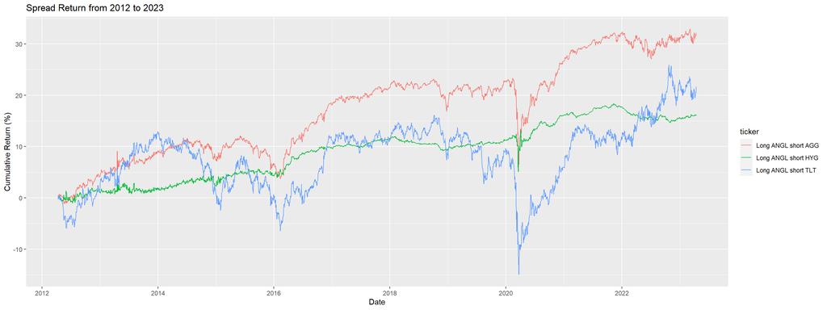

```r
df_spread_rtn %>%
  group_by(ticker) %>%
  mutate(cum_rtn = (cumprod(1 + rtn) - 1) * 100) %>%
  ggplot(aes(x = Date, y = cum_rtn, color = ticker))+
  geom_line() +
  labs(y = "Cumulative Return (%)", title = "Spread Return from 2012 to 2023")
```

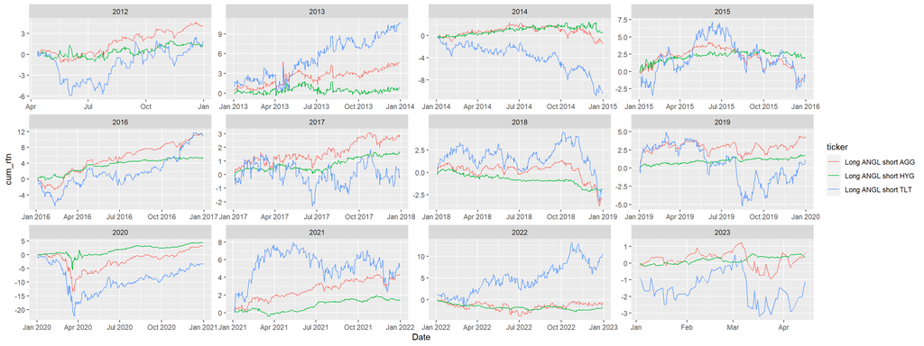

```r
df_spread_rtn %>%
  mutate(year = format(Date, format = "%Y")) %>%
  group_by(year, ticker) %>%
  mutate(cum_rtn = (cumprod(1 + rtn) - 1) * 100) %>%
  ggplot(aes(x = Date, y = cum_rtn, color = ticker)) +
  geom_line() +
  facet_wrap(~year, scales = "free")
```

## Run Regression on Spreads

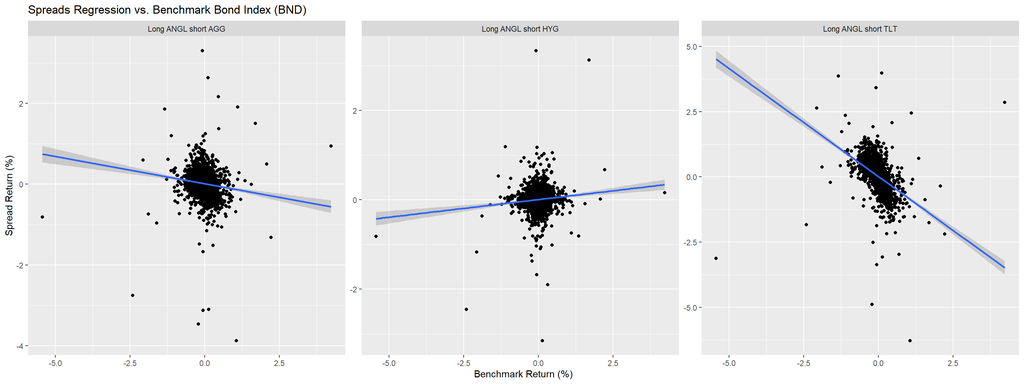

```r
# get benchmark returns


df_spread_combined <- df_spread_rtn %>%
  left_join(benchmark_rtn, by = "Date") %>%
  mutate(
    rtn = rtn * 100,
    benchmark_rtn = benchmark_rtn * 100)

ggplot(df_spread_combined, aes(x = benchmark_rtn, y = rtn)) +
  geom_point() +
  geom_smooth(method = "lm") +
  facet_wrap(~ticker, scale = "free") +
  labs(y = "Spread Return (%)", x = "Benchmark Return (%)",
       title = "Spreads Regression vs. Benchmark Bond Index (BND)")
```

It makes sense that we should have relatively flat lines since these are spreads. Although it would make sense to use Treasury to calculate Beta since we always take on bond risk premia by holding Long Fallen Angels, I thought the BND index would be better. It also makes sense to have negative beta really TLT is more like the benchmark to BND

## Strategy Idea

We are going to have two components of our strategy. Two returns streams to choose from and an indicator. We will always keep a contrarian long Fallen Angel position. In this case our option will be Long ANGL short HYG, and Long ANGL short AGG. Our indicator function will be a markov regime switching model based on Q/Q GDP changes. We are always extracting fallen-angel risk premia the markov regime strategy is more or less about adding junk bonds risk-premia harvesting.

Also I haven’t considered that I’ve been data-snooping this whole time. Ideally I would’ve used training and testing data so that I don’t manually overfit my model. Although the assumptions such as 50/50 L/S and the securities I picked are pretty reasonable.

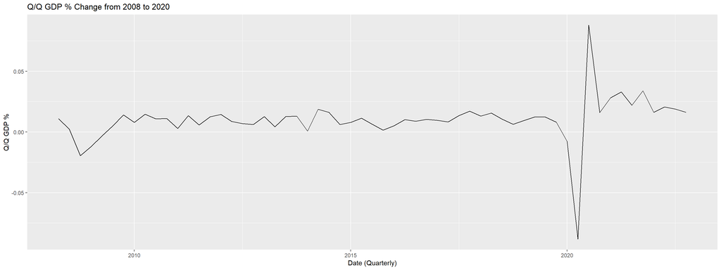

```r
file_path <- paste0(data_dir, "\\gdp.csv")
df_gdp_raw <- read.csv(file_path)

df_gdp_prep <- df_gdp_raw %>%
  mutate(
    DATE = as.Date(DATE),
    pct_change = value / lag(value) - 1) %>%
  drop_na()

df_gdp_prep %>%
  ggplot(aes(x = DATE, y = pct_change)) +
  geom_line() +
  labs(x = "Date (Quarterly)", y = "Q/Q GDP %", title = "Q/Q GDP % Change from 2008 to 2020")
```

## Generating the Markov Regime Switching Indicator

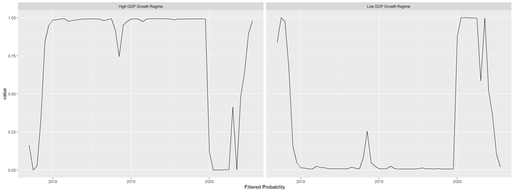

```r
df_gdp_lag <- df_gdp_prep %>%
  mutate(pct_change_lag = lag(pct_change)) %>%
  drop_na()

lrm = lm(df_gdp_lag$pct_change ~ df_gdp_lag$pct_change_lag)

# markov regime parameters
rsm = msmFit(lrm, k = 2, p = 0,
             sw = rep(TRUE, 3),
             control = list(parallel = F))

df_regime <- tibble(
  Date = df_gdp_lag$DATE,
  regime1 = rsm@Fit@filtProb[,1],
  regime2 = rsm@Fit@filtProb[,2],
  diff = regime1 - regime2, # the probs have to sum 1
  sign = sign(diff),
  lag_signal = lag(sign), # lag signal to avoid signal data snooping
  quarter = case_when(
    quarter(ymd(Date)) == 1 ~ "Q1",
    quarter(ymd(Date)) == 2 ~ "Q2",
    quarter(ymd(Date)) == 3 ~ "Q3",
    quarter(ymd(Date)) == 4 ~ "Q4")) # need to a column to merge on

df_regime %>%
  select(Date, 'High GDP Growth Regime' = regime1, 'Low GDP Growth Regime' = regime2) %>%
  melt(id.vars = "Date") %>%
  ggplot(aes(x = Date, y = value)) +
  facet_wrap(~variable) +
  geom_line()+
  labs(x = "Filtered Probability")
```

## Compare Strat Returns

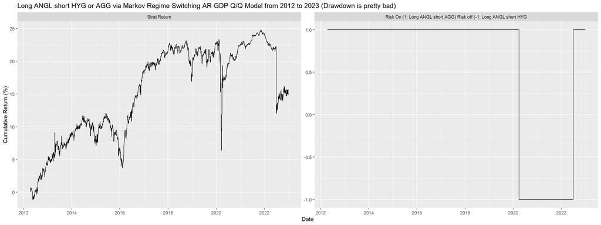

```r
df_quarter <- tibble(
  Date = seq(from = min(df_spread_rtn$Date), to = max(df_spread_rtn$Date), by = "day")) %>%
  mutate(
    quarter = case_when(
      quarter(ymd(Date)) == 1 ~ "Q1",
      quarter(ymd(Date)) == 2 ~ "Q2",
      quarter(ymd(Date)) == 3 ~ "Q3",
      quarter(ymd(Date)) == 4 ~ "Q4"),
    year_quarter = paste(format(Date, format = "%Y"), quarter)) %>%
  select(Date, year_quarter)

df_regime_quarter <- df_regime %>%
  mutate(
    year_quarter = paste(format(Date, format = "%Y"), quarter)) %>%
  select(year_quarter, lag_signal) %>%
  drop_na()

df_encoder <- tibble(
  lag_signal = c(1, -1),
  ticker_to_use = c("Long ANGL short AGG", "Long ANGL short HYG"))

df_signal_quarter <- df_quarter %>%
  left_join(
    y = df_regime_quarter,
    by = "year_quarter")

df_strat <- df_spread_rtn %>%
  left_join(
    df_signal_quarter,
    by = "Date") %>%
  left_join(
    y = df_encoder,
    by = "lag_signal") %>%
  filter(ticker == ticker_to_use) %>%
  mutate(cum_rtn = (cumprod(1 + rtn) - 1) * 100)

df_strat %>%
  select(Date, "Strat Return" = cum_rtn, "Risk On (1: Long ANGL short AGG) Risk off (-1: Long ANGL short HYG" = lag_signal) %>%
  melt(id.vars = "Date") %>%
  ggplot(aes(x = Date, y = value)) +
  geom_line() +
  facet_wrap(~variable, scale = "free") +
  labs(
    y = "Cumulative Return (%)",
    title = "Long ANGL short HYG or AGG via Markov Regime Switching AR GDP Q/Q Model from 2012 to 2023 (Drawdown is pretty bad)")
```

## Compare Strat Returns vs their Respective Securities

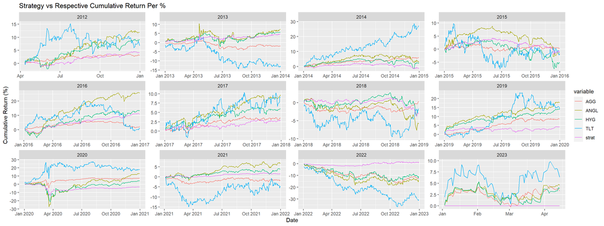

```r
df_rtn %>%
  select(Date, ticker, rtn) %>%
  pivot_wider(names_from = ticker, values_from = rtn) %>%
  left_join(
    df_strat %>%
      select(Date, rtn) %>%
      mutate(ticker = "strat") %>%
      pivot_wider(names_from = ticker, values_from = rtn),
    by = "Date") %>%
  melt(id.vars = "Date") %>%
  mutate(year = format(Date, format = "%Y")) %>%
  group_by(variable, year) %>%
  mutate(cum_rtn = (cumprod(1 + replace_na(value, 0)) - 1) * 100) %>%
  ggplot(aes(x = Date, y = cum_rtn, color = variable)) +
  geom_line() +
  facet_wrap(~year, scale = "free") +
  labs(y = "Cumulative Return (%)", title = "Strategy vs Respective Cumulative Return Per %")
```

## Compare Returns vs Spread

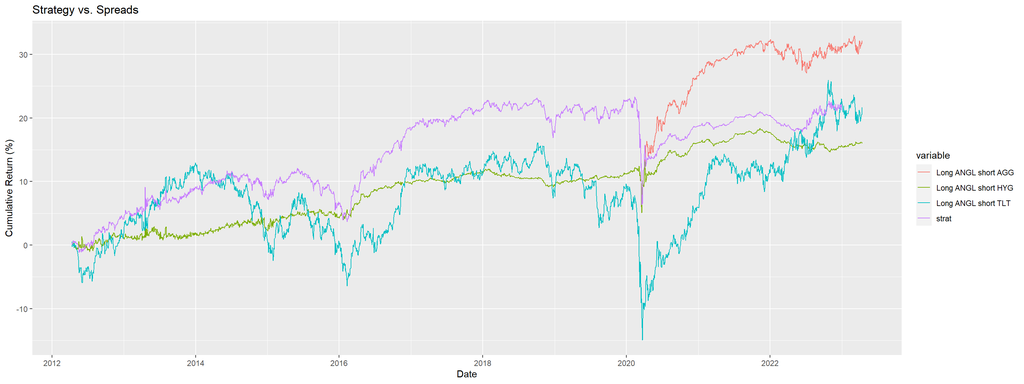

```r
df_spread_rtn %>%
  pivot_wider(names_from = ticker, values_from = rtn) %>%
  left_join(
    df_strat %>%
      select(Date, rtn) %>%
      mutate(ticker = "strat") %>%
      pivot_wider(names_from = ticker, values_from = rtn),
    how = "Date") %>%
  melt(id.vars = "Date") %>%
  group_by(variable) %>%
  mutate(cum_rtn = (cumprod(1 + value) - 1) * 100) %>%
  ggplot(aes(x = Date, y = cum_rtn, color = variable)) +
  geom_line() +
  labs(y = "Cumulative Return (%)", title = "Strategy vs. Spreads")
```

## Compare Strategy vs Spreads Per Year

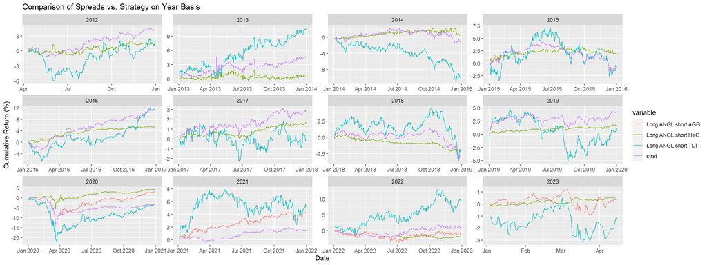

```r
df_spread_rtn %>%
  pivot_wider(names_from = ticker, values_from = rtn) %>%
  left_join(
    df_strat %>%
      select(Date, rtn) %>%
      mutate(ticker = "strat") %>%
      pivot_wider(names_from = ticker, values_from = rtn),
    how = "Date") %>%
  melt(id.vars = "Date") %>%
  mutate(year = format(Date, format = "%Y")) %>%
  group_by(variable, year) %>%
  mutate(cum_rtn = (cumprod(1 + value) - 1) * 100) %>%
  ggplot(aes(x = Date, y = cum_rtn, color = variable)) +
  geom_line() +
  facet_wrap(~year, scale = "free") +
  labs(y = "Cumulative Return (%)", title = "Comparison of Spreads vs. Strategy on Year Basis")
```

## Run Regression for strat

```r
df_regress <- df_strat %>%
  select(Date, rtn) %>%
  mutate(ticker = "strat") %>%
  left_join(
    y = df_rtn %>%
      filter(ticker == "TLT") %>%
      select(Date, benchmark_ticker = ticker, benchmark_rtn = rtn),
    by = "Date")

lm_strat <- lm(rtn ~ benchmark_rtn, df_regress)
summary(lm_strat)
```

```
##
## Call:
## lm(formula = rtn ~ benchmark_rtn, data = df_regress)
##
## Residuals:
##       Min        1Q    Median        3Q       Max
## -0.032974 -0.001023  0.000051  0.001078  0.032757
##
## Coefficients:
##                 Estimate Std. Error t value Pr(>|t|)
## (Intercept)    8.610e-05  5.351e-05   1.609    0.108
## benchmark_rtn -9.526e-02  5.898e-03 -16.152   <2e-16 ***
## ---
## Signif. codes:  0 '***' 0.001 '**' 0.01 '*' 0.05 '.' 0.1 ' ' 1
##
## Residual standard error: 0.00278 on 2697 degrees of freedom
##   (1 observation deleted due to missingness)
## Multiple R-squared:  0.0882, Adjusted R-squared:  0.08786
## F-statistic: 260.9 on 1 and 2697 DF,  p-value: < 2.2e-16
```

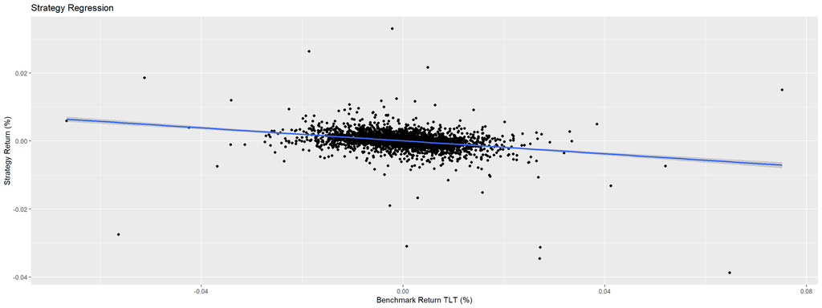

```r
df_regress %>%
  ggplot(aes(x = benchmark_rtn, y = rtn)) +
  geom_point() +
  geom_smooth(method = "lm") +
  labs(x = "Benchmark Return TLT (%)", y = "Strategy Return (%)", title = "Strategy Regression")
```

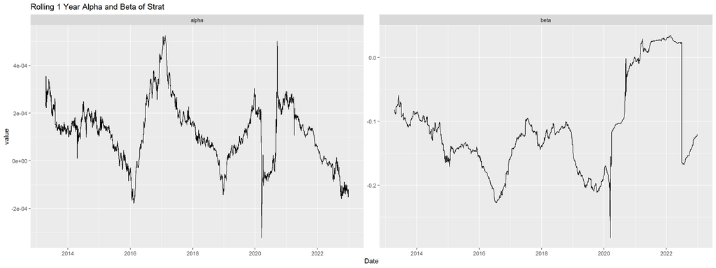

```r
## Let's seperate out Beta and Alpha and compare
rolling_regress <- roll_lm(x = df_regress$benchmark_rtn, y = df_regress$rtn, width = 252)

regress_coefs <- tibble(
  alpha = rolling_regress$coefficients[, 1],
  beta = rolling_regress$coefficients[, 2]) %>%
  mutate(Date = df_regress$Date) %>%
  drop_na() %>%
  melt(id.vars = "Date")

regress_coefs %>%
  ggplot(aes(x = Date, y = value)) +
  geom_line() +
  facet_wrap(~variable, scale = "free") +
  labs(title = "Rolling 1 Year Alpha and Beta of Strat")
```

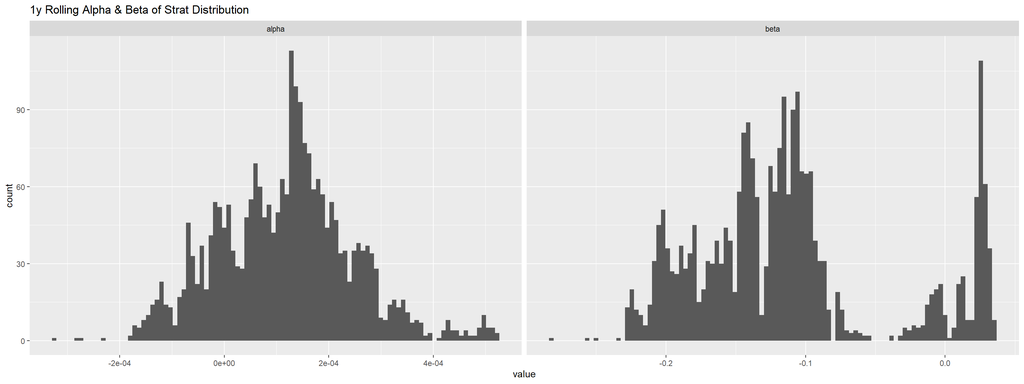

```r
regress_coefs %>%
  ggplot(aes(x = value)) +
  geom_histogram(bins = 100) +
  facet_grid(~variable, scale = "free") +
  labs(title = "1y Rolling Alpha & Beta of Strat Distribution")
```

It is a little surprising to see what looks like positive skew and positive expected value alpha. It does somewhat make sense since I’m assuming there is contrarian money to be made and thus we are long volatility. I do not like the distribution of beta, since my beta-hedge error / portfolio maintenance will require constant buying / selling. But then again, I didn’t optimize to minimize beta its 50/50 L/S fully-funded daily rebalance. The rolling alpha and beta graphs above the histogram make me think that there is a problem with the data.